# Linear Algebra

```python
import matplotlib.pyplot as plt
%matplotlib inline
from sympy import *
import numpy as np
from numpy import mat, dot, array
from numpy.linalg import norm, inv, pinv
from IPython.display import YouTubeVideo
from scipy.linalg import lu
```

```python
init_printing()
```

1. Intro to Vectors
   1. Intro to Vectors
   2. Lengths and Dot Products
   3. [Matrices]
      1. Multiplying
2. Solving Linear Equations
   1. Vectors and Linear Equations
3. Factorization into $\mathbf{A = LU}$
4. Transposes, Permutations, Vector Spaces

# Intro to Vectors

## Lengths Dot Products

$\mathbf{v \cdot w} = v_1w_1 + v_2w_2$

if $\mathbf{v \cdot w} = v_1w_1 + v_2w_2=0$

$\mathbf{v}$ and $\mathbf{w}$ are $\perp$

$\mathbf{v \cdot w} = \mathbf{w \cdot v}$

more dot-product

$\sum v_iw_i = \mathbf{v \cdot w}$

$\|\mathbf{v}\|^2 = \mathbf{v \cdot v}$

length $\|\mathbf{v}\| = \sqrt{\mathbf{v \cdot v}}$

### Unit Vectors

$\mathbf{u \cdot u}=1$

$\mathbf{u}$ is a unit vector

$\mathbf{i}=\begin{bmatrix} 1 \\0 \end{bmatrix}$ $\mathbf{j}=\begin{bmatrix} 0 \\1 \end{bmatrix}$ $\mathbf{u}=\begin{bmatrix} \cos \theta \\ \sin\theta \end{bmatrix}$

$\mathbf{u}$ is the unit vector that makes angle $\theta$ with the $x$ axis

To get a unit vector, divide any $\mathbf{v}$ by it's length $\|\mathbf{v}\|$

### The angle between two vectors

$\mathbf{v \cdot w} = v_1w_1 + v_2w_2=0$ when $\mathbf{v}$ and $\mathbf{u}$ are $\perp$

The vector $\mathbf{v} = 0$ is $\perp$ to all vectors because $\mathbf{v \cdot 0}$ is always 0.

$ \begin{cases} \mathbf{v\cdot w}>0,&\theta < 90^{\circ}\\ \mathbf{v\cdot w}<0,&\theta > 90^{\circ}\\ \mathbf{v\cdot w}=0,&\theta = 90^{\circ}\\ \end{cases} $

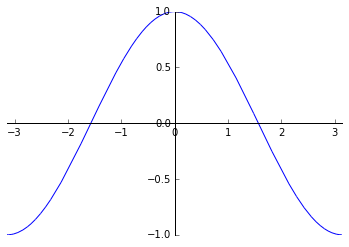

```python
x = symbols('x')
fx = cos(x)
fx
plot(fx, xlim = [-3.14, 3.14]);
```

Unit vectors $\mathbf{u}$ and $\mathbf{U}$ at angle $\theta$ have $\mathbf{u \cdot U} = \cos \theta$

The dotproduct of unit vectors is $[-1, 1]$

What if $\mathbf{v \text{ & } w}$ are not unit vectors? Divide by their length to get thei respsective unit vectors

$\dfrac{\mathbf{v\cdot w}}{\|w\|\|v\|} = \cos \theta$

$\therefore$

$\mathbf{|v \cdot w|} < \mathbf{\|v\|\|w\|}$

and

$\mathbf{\|v + w}\| < \mathbf{\|v\|+\|w\|}$

```python
v = array([1, 2, 3])
w = array([1, 1, 1])
```

```python
np.dot(v, w)
```

$$6$$

```python
np.linalg.norm(v)
```

$$3.74165738677$$

```python
sum([_**2 for _ in v])**0.5
```

$$3.74165738677$$

```python
# cosine theta between w and v
dot(v, w)/(norm(v) * norm(w))
```

$$0.925820099773$$

```python
# theta between w and v
acos(dot(v, w)/(norm(v) * norm(w)))
```

$$0.38759668665518$$

```python
init_printing(pretty_print=False)
v = array([3, 4])
w = array([4, 3])
dot(v, w)/(norm(v) * norm(w))
```

```
0.96
```

## Matrices

**difference matrix**

$\mathbf{Ax} = \begin{bmatrix} 1& 0& 0 \\ -1& 1& 0 \\ 0& -1& -1 \\ \end{bmatrix} \begin{bmatrix} x_1 \\ x_2 \\ x_3 \\ \end{bmatrix}= \begin{bmatrix} \mathbf{x_1} \\ \mathbf{x_2 - x_1} \\ \mathbf{x_3 - x_2} \\ \end{bmatrix}= \begin{bmatrix} b_1 \\ b_2 \\ b_3 \\ \end{bmatrix}= \mathbf{b} $

**matrix times vector**

$\mathbf{Ax} = \begin{bmatrix} \\ \mathbf{u}& \mathbf{v}& \mathbf{w} \\ \\ \end{bmatrix} \begin{bmatrix} c\\d\\e\\ \end{bmatrix}=c\mathbf{u} + d\mathbf{v} + e\mathbf{w} $

**dot products with rows**

$\mathbf{Ax} = \begin{bmatrix} 1&0&0\\ -1&0&0\\ 0&-1&1\\ \end{bmatrix} \begin{bmatrix} x_1 \\ x_2 \\ x_3 \\ \end{bmatrix}= \begin{bmatrix} (1, 0, 0)\cdot (x_1, x_2, x_3) \\ (-1, 1, 0)\cdot (x_1, x_2, x_3) \\ (0, -1, 1)\cdot (x_1, x_2, x_3) \\ \end{bmatrix} $

Column form way. Easiest to remember probably:

$\mathbf{Ax} = \begin{bmatrix} 1&0&0\\ -1&0&0\\ 0&-1&1\\ \end{bmatrix} \begin{bmatrix} x_1 \\ x_2 \\ x_3 \\ \end{bmatrix}= x_1 \begin{bmatrix} 1\\-1\\0\\ \end{bmatrix}+ x_2 \begin{bmatrix} 0\\0\\-1\\ \end{bmatrix}+ x_3 \begin{bmatrix} 0\\0\\1\\ \end{bmatrix} $

**Linear Equations**

Up till now looking at equations in the form

$\mathbf{Ax = b}$

Now let's switch it up so

$\mathbf{b = Ax}$ where $\mathbf{x}$ is the unknown

### Inverse Matrix

$\mathbf{Ax = b}$ is solved by

$\mathbf{x = A^{-1}b = Sb}$

# Solving Linear Equations

## Vectors and Linear Equations

The central problem of linear algebra is to solve a system of equations

matrix x column = column

row x matrix = row

**Step 1**

$E_{21} = \begin{bmatrix} 1&0&0\\ -3&1&0\\ 0&0&1\\ \end{bmatrix}$

$\begin{bmatrix} 1&0&0\\ -3&1&0\\ 0&0&1\\ \end{bmatrix} \begin{bmatrix} 1&2&1\\ 3&8&1\\ 0&4&1\\ \end{bmatrix}= \begin{bmatrix} 1&2&1\\ 0&2&-2\\ 0&4&1\\ \end{bmatrix}$

```python
-3*1 + 1*1 + 0*1
```

```
-2
```

**Step 2**

$ E_{32}=\begin{bmatrix} 1&0&0\\ 0&1&0\\ 0&-2&1\\ \end{bmatrix}$

$\begin{bmatrix} 1&0&0\\ 0&1&0\\ 0&-2&1\\ \end{bmatrix} \begin{bmatrix} 1&2&1\\ 0&2&-2\\ 0&4&1\\ \end{bmatrix}= \begin{bmatrix} 1&2&1\\ 0&2&-2\\ 0&0&5\\ \end{bmatrix}$

This is what we did to get $\mathbf{U}$, which is the upper triangle matrix

$\mathbf{E_{32}(E_{21}A)=U}$

$\mathbf{(E_{32}E_{21})A=U}$

You can't mess around with the order of the matrices, but you can mess around with the parenthesis.

$\mathbf{AB \neq BA}$

**Permutation Matrix**

$\mathbf{p}=\begin{bmatrix} 0&1\\ 1&0\\ \end{bmatrix} $

$\mathbf{p}$ for permutation matrix

$\begin{bmatrix} 0&1\\ 1&0\\ \end{bmatrix} \begin{bmatrix} a&b\\ c&d\\ \end{bmatrix}= \begin{bmatrix} c&d\\ a&b\\ \end{bmatrix}$

$\mathbf{B} \begin{bmatrix} a&b\\ c&d\\ \end{bmatrix}= \begin{bmatrix} b&a\\ d&c\\ \end{bmatrix}$

$\mathbf{B}$ does not exist. If you want to do exercise column-wise, you have to put the matrix on the right.

$ \begin{bmatrix} a&b\\ c&d\\ \end{bmatrix} \mathbf{B} = \begin{bmatrix} b&a\\ d&c\\ \end{bmatrix} $

$ \begin{bmatrix} a&b\\ c&d\\ \end{bmatrix} \begin{bmatrix} 0&1\\ 1&0\\ \end{bmatrix} = \begin{bmatrix} b&a\\ d&c\\ \end{bmatrix} $

Think not about how to get from $\mathbf{A \to U}$, instead think about $\mathbf{U \to A}$

Think about the inverse matrix.

$\mathbf{AA^{-1} = I}$

$\mathbf{I} = \begin{bmatrix} 1&0&0\\ 0&1&0\\ 0&0&1\\ \end{bmatrix}$

### Multiplying Matrices

```python
vid = 'OMA2Mwo0aZg'
YouTubeVideo(vid, width='600', height='400')
```

[video not shown]

$\mathbf{E} = \begin{bmatrix} 0&3&5\\ 5&5&2\\ \end{bmatrix}$ $\mathbf{D} = \begin{bmatrix} 3&4\\ 3&-2\\ 4&-2\\ \end{bmatrix}$

What is $\mathbf{ED}$?

What is $\mathbf{E}$ is 2x3.

What is $\mathbf{D}$ is 3x2.

So we can do this because columns of the second one are equal to the rows of the first one.

In the end we get a 2x2 matrix.

for the index $ij$, get the $i^{th}$ row from $\mathbf{E}$, and the $j^{th}$ column from $\mathbf{D}$

$\mathbf{E\cdot D} = \begin{bmatrix} \text{dot(1st row E & 1st column E)}&\text{dot(1st row E & 2nd column E)}\\ \text{dot(2nd row E & 1st column E)}&\text{dot(2nd row E & 2nd column E)}\\ \end{bmatrix}$

$\mathbf{E\cdot D} = \begin{bmatrix} 0\cdot 3 + 3 \cdot 3 + 5 \cdot 4& 0\cdot 4 + 3 \cdot -2 + 5 \cdot -2& \\ 5\cdot 3 + 5 \cdot 3 + 2 \cdot 4& 5\cdot 4 + 5 \cdot -2 + 2 \cdot -2& \\ \end{bmatrix}$

```python
init_printing()
E = array([[0, 3, 5], [5, 5 ,2]])
Matrix(E)
```

$$\left[\begin{matrix}0 & 3 & 5\\5 & 5 & 2\end{matrix}\right]$$

```python
D = array([[3, 4], [3, -2], [4, -2]])
Matrix(D)
```

$$\left[\begin{matrix}3 & 4\\3 & -2\\4 & -2\end{matrix}\right]$$

```python
Matrix(np.dot(E, D))
```

$$\left[\begin{matrix}29 & -16\\38 & 6\end{matrix}\right]$$

## Ways to multiply a matrix

$\mathbf{AB=C}$

$\mathbf{A}: m \times n$

$\mathbf{B}: n \times p$

$\mathbf{C}: m \times p$

$C_{ij} = \mathbf{A_i} \cdot \mathbf{B_j}$

$C_{34}$ = dot product(3rd row $\mathbf{A}$, 4th column $\mathbf{B}$)

$C_{34} = a_{31}b_{14} + a_{32}b_{24}... = \sum\limits_{k=1}^n a_{3k}b_{k4}$

$\mathbf{AB=C}$

$\mathbf{A}: m \times n$

$\mathbf{B}: n \times p$

$\mathbf{C}: m \times p$

$ \begin{bmatrix} \\ &\mathbf{A}&\\ \\\end{bmatrix} \begin{bmatrix} \\ &\mathbf{B}&\\ \\\end{bmatrix}= \begin{bmatrix} \\ &\mathbf{C}& \\ \\\end{bmatrix}$

Rows of $\mathbf{C}$ are combinations of rows of $\mathbf{B}$

Column of $\mathbf{A}$ $\times$ row of $\mathbf{B}$

$m\times 1$ and $1 \times p = m \times p$

$ \begin{bmatrix} 2\\ 3\\ 4\\ \end{bmatrix} \begin{bmatrix} 1&6\\ \end{bmatrix}= \begin{bmatrix} 2&12\\ 3&18\\ 4&24\\ \end{bmatrix}$

The columns are combinations of the first one.

The rows are combinations of the second one!

$\mathbf{AB}$ = sum of (cols of $\mathbf{A}) \times$ (rows of $\mathbf{B})$

$ \begin{bmatrix} 2&7\\ 3&8\\ 4&9\\ \end{bmatrix} \begin{bmatrix} 1&6\\ 0&0\\ \end{bmatrix}= \begin{bmatrix} 2\\3\\4\\ \end{bmatrix} \begin{bmatrix} 1&6\\ \end{bmatrix}+ \begin{bmatrix} 7\\8\\9\\ \end{bmatrix} \begin{bmatrix} 0&0\\ \end{bmatrix}= \begin{bmatrix} 0&0\\ \end{bmatrix}$

$ \begin{bmatrix} 2&12\\ 3&18\\ 4&24\\ \end{bmatrix}+ \begin{bmatrix} 0&0\\ 0&0\\ 0&0\\ \end{bmatrix}= \begin{bmatrix} 2&12\\ 3&18\\ 4&24\\ \end{bmatrix} $

all the rows lie on the vector $[1, 6]$

all the colums lie on the vector $[2, 3, 4]$

```python
a =array([[2, 7], [3, 8], [4, 9]])
b =array([[1, 6], [0, 0]])
Matrix(a), Matrix(b)
```

$$\begin{pmatrix}\left[\begin{matrix}2 & 7\\3 & 8\\4 & 9\end{matrix}\right], & \left[\begin{matrix}1 & 6\\0 & 0\end{matrix}\right]\end{pmatrix}$$

```python
Matrix(dot(a, b))
```

$$\left[\begin{matrix}2 & 12\\3 & 18\\4 & 24\end{matrix}\right]$$

### Inverses

$\mathbf{A^{-1}A} = I = \mathbf{AA^{-1}}$, for a square matrix

If $\mathbf{A^{-1}}$ exists, it's called invertible or nonsingular

### Singular case

No inverse

Example of singular matrix:

$\mathbf{A}= \begin{bmatrix} 1&3\\ 2&6\\ \end{bmatrix} $

```python
a = np.array([[1, 3], [2, 6]])
Matrix(a)
```

$$\left[\begin{matrix}1 & 3\\2 & 6\end{matrix}\right]$$

```python
inv(a)
```

[output not shown]

$\mathbf{Ax}= \begin{bmatrix} 1&3\\ 2&6\\ \end{bmatrix} \begin{bmatrix} 3\\ -1\\ \end{bmatrix}= \begin{bmatrix} 0\\ 0\\ \end{bmatrix}$

$\mathbf{x}\neq 0$

If you find the non-negative $\mathbf{x}$, then $\mathbf{A^{-1}}$ does not exist

**another example**

$\mathbf{A}= \begin{bmatrix} 1&3\\ 2&7\\ \end{bmatrix}$, the columns point in different directions

$\mathbf{AA^{-1}=I}$

$\begin{bmatrix} 1&3\\ 2&7\\ \end{bmatrix} \begin{bmatrix} a&c\\ b&d\\ \end{bmatrix}= \begin{bmatrix} 1&0\\ 0&1\\ \end{bmatrix} $

$\mathbf{A} \times$ column $j$ of $\mathbf{A^{-1}}=$ column $j$ of $\mathbf{I}$

### Gauss Jordan

Solves 2 equations at once

$\begin{bmatrix} 1&3\\ 2&7\\ \end{bmatrix} \begin{bmatrix} a\\ b\\ \end{bmatrix}= \begin{bmatrix} 1\\ 0\\ \end{bmatrix} $

$\begin{bmatrix} 1&3\\ 2&7\\ \end{bmatrix} \begin{bmatrix} c\\ d\\ \end{bmatrix}= \begin{bmatrix} 0\\ 1\\ \end{bmatrix} $

Augmented Matrix:

$\begin{bmatrix} 1&3&1&0\\ 2&7&0&1\\ \end{bmatrix}\to \begin{bmatrix} 1&3&1&0\\ 0&1&-2&1\\ \end{bmatrix}\to \begin{bmatrix} 1&0&7&-3\\ 0&1&-2&1\\ \end{bmatrix} $

```python
ainv = array([[7, -3],[-2, 1]])
a = array([[1, 3],[2, 7]])
```

```python
Matrix(dot(a, ainv))
```

$$\left[\begin{matrix}1 & 0\\0 & 1\end{matrix}\right]$$

$\mathbf{EAI = IA^{-1}}$

```python
A = array([[1,0, 0, 0], [1, 1, 0, 0], [1,2, 1, 0], [1, 3, 3, 1]])
```

```python
Matrix(A)
```

$$\left[\begin{matrix}1 & 0 & 0 & 0\\1 & 1 & 0 & 0\\1 & 2 & 1 & 0\\1 & 3 & 3 & 1\end{matrix}\right]$$

```python
Matrix(inv(A))
```

$$\left[\begin{matrix}1.0 & 0.0 & 0.0 & 0.0\\-1.0 & 1.0 & 0.0 & 0.0\\1.0 & -2.0 & 1.0 & 0.0\\-1.0 & 3.0 & -3.0 & 1.0\end{matrix}\right]$$

```python
B = array([[1,0, 0, 0], [0, 1, 0, 0], [0,1, 1, 0], [0, 1, 2, 1]])
Matrix(B)
```

$$\left[\begin{matrix}1 & 0 & 0 & 0\\0 & 1 & 0 & 0\\0 & 1 & 1 & 0\\0 & 1 & 2 & 1\end{matrix}\right]$$

```python
# fun
Matrix(dot(B, inv(A)))
```

$$\left[\begin{matrix}1.0 & 0.0 & 0.0 & 0.0\\-1.0 & 1.0 & 0.0 & 0.0\\0.0 & -1.0 & 1.0 & 0.0\\-2.22044604925031 \cdot 10^{-16} & 0.0 & -1.0 & 1.0\end{matrix}\right]$$

## Factorization into $\mathbf{A = LU}$

http://ocw.mit.edu/courses/mathematics/18-06sc-linear-algebra-fall-2011/ax-b-and-the-four-subspaces/factorization-into-a-lu/

$\mathbf{AA^{-1}=I=A^{-1}A}$

$\mathbf{(AB)(B^{-1}A^{-1})=I}$

$\mathbf{ABB^{-1}A^{-1}=I=I^T}$

$\mathbf{(A^{-1})^TA^T}=\mathbf{I}$

**Example**

$ \mathbf{E_{21}} \stackrel{\mathbf{A}}{ \begin{bmatrix} 2&1\\ 8&7\\ \end{bmatrix} }= \stackrel{\mathbf{U}}{ \begin{bmatrix} 2&1\\ 0&3\\ \end{bmatrix} } $

Now figure out $\mathbf{E_{21}}$...which he somehow does in his head. If you aint as matrixly inclined you do $\mathbf{E_{21} = UA^{-1}}$

$ \stackrel{\mathbf{E_{21}}}{ \begin{bmatrix} 1&0\\ -4&1\\ \end{bmatrix} } \stackrel{\mathbf{A}}{ \begin{bmatrix} 2&1\\ 8&7\\ \end{bmatrix} }= \stackrel{\mathbf{U}}{ \begin{bmatrix} 2&1\\ 0&3\\ \end{bmatrix} } $

$\mathbf{L}$ he also figures out in his head.

$\mathbf{A=LU}$

$\mathbf{AU^{-1}=L}$

$ \stackrel{\mathbf{A}}{ \begin{bmatrix} 2&1\\ 8&7\\ \end{bmatrix} }= \stackrel{\mathbf{L}}{ \begin{bmatrix} 1&0\\ 4&1\\ \end{bmatrix} } \stackrel{\mathbf{U}}{ \begin{bmatrix} 2&1\\ 0&3\\ \end{bmatrix} } $

```python
a = array([[2,1], [8,7]])
u = array([[2, 1],[0, 3]])
Matrix(dot(u, inv(a)))
```

$$\left[\begin{matrix}1.0 & 5.55111512312578 \cdot 10^{-17}\\-4.0 & 1.0\end{matrix}\right]$$

```python
l=dot(a, inv(u))
Matrix(l)
```

$$\left[\begin{matrix}1.0 & 0.0\\4.0 & 1.0\end{matrix}\right]$$

$\mathbf{U}$ stands for upper triangular

$\mathbf{L}$ stands for lower triangular

$\mathbf{D}$ stands for diagonal

$ \stackrel{\mathbf{U_{old}}}{ \begin{bmatrix} 2&1\\ 0&3\\ \end{bmatrix} }= \stackrel{\mathbf{D}}{ \begin{bmatrix} 2&0\\ 0&3\\ \end{bmatrix} } \stackrel{\mathbf{U_{new}}}{ \begin{bmatrix} 1&\frac{1}{2}\\ 0&1\\ \end{bmatrix} } $

$ \stackrel{\mathbf{A}}{ \begin{bmatrix} 2&1\\ 8&7\\ \end{bmatrix} }= \stackrel{\mathbf{L}}{ \begin{bmatrix} 1&0\\ 4&1\\ \end{bmatrix} } \stackrel{\mathbf{D}}{ \begin{bmatrix} 2&0\\ 0&3\\ \end{bmatrix} } \stackrel{\mathbf{U}}{ \begin{bmatrix} 1&\frac{1}{2}\\ 0&1\\ \end{bmatrix} } $

He got the deconstruction of $\mathbf{U_{old}}$ easily because $\mathbf{D}$ is a diagonal matrix and therefore easy to multiply. Hint: Think about how one uses the Identity matrix

```python
l = array([[1, 0], [4, 1]])
u = array([[1, 0.5], [0, 1]])
d = array([[2, 0], [0, 3]])
Matrix(d), Matrix(l), Matrix(u)
```

$$\begin{pmatrix}\left[\begin{matrix}2 & 0\\0 & 3\end{matrix}\right], & \left[\begin{matrix}1 & 0\\4 & 1\end{matrix}\right], & \left[\begin{matrix}1.0 & 0.5\\0.0 & 1.0\end{matrix}\right]\end{pmatrix}$$

```python
Matrix(dot(dot(l, d), u))==Matrix(a)
```

```
True
```

That was a $2\times2$. Let's imagine a $3\times3$

First step is to get a $0$ is the $A_{21}$ position

$\mathbf{E_{21}A}$

Next step is to get a $0$ is the $A_{31}$ position

$\mathbf{E_{31}E_{21}A}$

Final step is to get a $0$ is the $A_{32}$ position

$\mathbf{E_{32}E_{31}E_{21}A=U}$ (no row exchanges)

$\mathbf{A=E_{21}^{-1}E_{31}^{-1}E_{32}^{-1}U}$

$\mathbf{A=LU}$

remember

$\mathbf{(AB)(B^{-1}A^{-1})=I}$

$\therefore$

$(\mathbf{E_{32}E_{31}E_{21})(E_{21}^{-1}E_{31}^{-1}E_{32}^{-1}) = I}$

**Example**

$ \stackrel{\mathbf{E_{32}}}{ \begin{bmatrix} 1&0&0\\ 0&1&0\\ 0&-5&1\\ \end{bmatrix} } \stackrel{\mathbf{E_{31}}}{ \begin{bmatrix} 1&0&0\\ 0&1&0\\ 0&0&1\\ \end{bmatrix} } \stackrel{\mathbf{E_{21}}}{ \begin{bmatrix} 1&0&0\\ -2&1&0\\ 0&0&1\\ \end{bmatrix} }= $

$ \stackrel{\mathbf{E_{32}}}{ \begin{bmatrix} 1&0&0\\ 0&1&0\\ 0&-5&1\\ \end{bmatrix} } \stackrel{\mathbf{E_{21}}}{ \begin{bmatrix} 1&0&0\\ -2&1&0\\ 0&0&1\\ \end{bmatrix} }= $

```python
e32 = mat([[1, 0, 0], [0, 1, 0], [0, -5, 1]])
e21 = mat([[1, 0, 0], [-2, 1, 0], [0, 0, 1]])
Matrix(e32), Matrix(e21)
```

$$\begin{pmatrix}\left[\begin{matrix}1 & 0 & 0\\0 & 1 & 0\\0 & -5 & 1\end{matrix}\right], & \left[\begin{matrix}1 & 0 & 0\\-2 & 1 & 0\\0 & 0 & 1\end{matrix}\right]\end{pmatrix}$$

```python
Matrix(e32 * e21)
```

$$\left[\begin{matrix}1 & 0 & 0\\-2 & 1 & 0\\10 & -5 & 1\end{matrix}\right]$$

He doesn't like the 10 in row 3. It got there from row 1's downward cascading effects.

Continuing with same example, let's do the inverses

$(\mathbf{E_{32}E_{31}E_{21})(E_{21}^{-1}E_{31}^{-1}E_{32}^{-1}) = I}$

Notice how stupidly easy it is to take the inverse of $\mathbf{E_{ij}}$

$ \stackrel{\mathbf{E_{21}}}{ \begin{bmatrix} 1&0&0\\ -2&1&0\\ 0&0&1\\ \end{bmatrix} }, \stackrel{\mathbf{E_{21}^{-1}}}{ \begin{bmatrix} 1&0&0\\ 2&1&0\\ 0&0&1\\ \end{bmatrix} }$

$ \stackrel{\mathbf{E_{31}}}{ \begin{bmatrix} 1&0&0\\ 0&1&0\\ 0&0&1\\ \end{bmatrix} }, \stackrel{\mathbf{E_{31}^{-1}}}{ \begin{bmatrix} 1&0&0\\ 0&1&0\\ 0&0&1\\ \end{bmatrix} }$

$ \stackrel{\mathbf{E_{32}}}{ \begin{bmatrix} 1&0&0\\ 0&1&0\\ 0&-5&1\\ \end{bmatrix} }, \stackrel{\mathbf{E_{32}^{-1}}}{ \begin{bmatrix} 1&0&0\\ 0&1&0\\ 0&5&1\\ \end{bmatrix} } $

$\mathbf{E_{21}^{-1}E_{31}^{-1}E_{32}^{-1}} =$

$\stackrel{\mathbf{E_{21}^{-1}}}{ \begin{bmatrix} 1&0&0\\ 2&1&0\\ 0&0&1\\ \end{bmatrix} } \stackrel{\mathbf{E_{32}^{-1}}}{ \begin{bmatrix} 1&0&0\\ 0&1&0\\ 0&5&1\\ \end{bmatrix} }= \stackrel{\mathbf{L}}{ \begin{bmatrix} 1&0&0\\ 2&1&0\\ 0&5&1\\ \end{bmatrix} } $

$\mathbf{EA=U}$

$\mathbf{A=LU}$

If no row exchanges, multipliers go directly into $\mathbf{L}$

getting $\mathbf{L}$ is less work

**How many operations on a $n\times n$ matrix $\mathbf{A}$?**

say $n=100$

one operation = (multiply + subtract)

$100^2$ for the 1st operation. Need operation on each number in matrix

$99^2$ for the 2nd operation. Need operation on each number in matrix

$98^2$ for the 3rd operation. Need operation on each number in matrix

$\text{operations} = 100^2 + 99^2 ... 2^2 + 1^2$

$\sum\limits_{i=1}^n n^2 \approx \dfrac{1}{3}n^3$

$\int_1^{n} n^2 \, dn = \dfrac{1}{3}n^3$

That's what it cost on $\mathbf{A}$ on the left to split it into $\mathbf{L}$ and $\mathbf{U}$

The cost on $\mathbf{B}$ on the right is $n^2$

### Permutations

$\mathbf{P}$: execute row exchanges

If a $0$ shows up in a pivot position, you need the liberty to exchange the row with one below. You might have to do it more than one time

You start with $\mathbf{A}$, you start elimination, and you may find out that you need row exchanges

$\mathbf{A = LU}$

[figure not shown]

The implicit $\mathbf{P}$ is above $\mathbf{I}$

Software doesn't like pivots close to $0$, so it'll do exchanges that alegbra says is unnecessary

$\mathbf{PA = LU}$ is the description with row exchanges

$\mathbf{P}:$ identity matrix with reordered rows

$n!$ possible $\mathbf{P}$'s, where $\mathbf{P}$ is $n\times n$

$\mathbf{P^{-1} = P^T}$

$\mathbf{P^{T}P=I}$

**What happens if there are row exchanges?**

$\mathbf{P} = \begin{bmatrix} 1&0&0\\ 0&1&0\\ 0&0&1\\ \end{bmatrix}$ , $\begin{bmatrix} 0&1&0\\ 1&0&0\\ 0&0&1\\ \end{bmatrix}$ , $\begin{bmatrix} 0&0&1\\ 0&1&0\\ 1&0&0\\ \end{bmatrix}$ , $\begin{bmatrix} 1&0&0\\ 0&0&1\\ 0&1&0\\ \end{bmatrix}$ $, \begin{bmatrix} 0&1&0\\ 0&0&1\\ 1&0&0\\ \end{bmatrix}$ $, \begin{bmatrix} 0&0&1\\ 1&0&0\\ 0&1&0\\ \end{bmatrix}$

6 $\mathbf{P} = 3!$

$\mathbf{P^{-1} = P^T}$

For a $4\times 4$ matrix, there are $4!$ of $\mathbf{P}$

**hw**

What E puts A into triangular form EA=U.

```python
a = mat([[1, 3, 0], [2, 4, 0], [2, 0, 1]])
e21 = mat([[1, 0, 0], [-2, 1, 0], [-2, 0, 1]])
e32 = mat([[1, 0, 0], [0, 1, 0], [0, -3, 1]])
Matrix(a), Matrix(e21), Matrix(e32)
```

$$\begin{pmatrix}\left[\begin{matrix}1 & 3 & 0\\2 & 4 & 0\\2 & 0 & 1\end{matrix}\right], & \left[\begin{matrix}1 & 0 & 0\\-2 & 1 & 0\\-2 & 0 & 1\end{matrix}\right], & \left[\begin{matrix}1 & 0 & 0\\0 & 1 & 0\\0 & -3 & 1\end{matrix}\right]\end{pmatrix}$$

```python
# damn. python linalg syntax blows. re: use np.linalg.mat instead of np.linalg.array
u = e32 * e21 * a
Matrix(u)
```

$$\left[\begin{matrix}1 & 3 & 0\\0 & -2 & 0\\0 & 0 & 1\end{matrix}\right]$$

```python
l = inv(e21)  * inv(e32)
```

```python
Matrix(l)
```

$$\left[\begin{matrix}1.0 & 0.0 & 0.0\\2.0 & 1.0 & 0.0\\2.0 & 3.0 & 1.0\end{matrix}\right]$$

```python
Matrix(l * u)
```

$$\left[\begin{matrix}1.0 & 3.0 & 0.0\\2.0 & 4.0 & 0.0\\2.0 & 0.0 & 1.0\end{matrix}\right]$$

```python
a, b, c, d = symbols('a,b,c,d')
```

```python
A = mat([[a, a, a, a], [a, b, b,b], [a, b, c, c], [a, b, c,d]])
```

```python
# calced e's by paper
e21 = mat([[1, 0,0,0], [-1, 1, 0,0], [-1,0, 1, 0], [-1, 0, 0,1]])
e32 = mat([[1, 0,0,0], [0, 1, 0,0], [0,-1, 1, 0], [0, -1, 0,1]])
e43 = mat([[1, 0,0,0], [0, 1, 0,0], [0,0, 1, 0], [0, 0, -1,1]])
```

```python
Matrix(e21 * A)
```

$$\left[\begin{matrix}a & a & a & a\\0 & - a + b & - a + b & - a + b\\0 & - a + b & - a + c & - a + c\\0 & - a + b & - a + c & - a + d\end{matrix}\right]$$

```python
Matrix(e32 * e21 * A)
```

$$\left[\begin{matrix}a & a & a & a\\0 & - a + b & - a + b & - a + b\\0 & 0 & - b + c & - b + c\\0 & 0 & - b + c & - b + d\end{matrix}\right]$$

```python
U = e43 * e32 * e21 * A
Matrix(U)
```

$$\left[\begin{matrix}a & a & a & a\\0 & - a + b & - a + b & - a + b\\0 & 0 & - b + c & - b + c\\0 & 0 & 0 & - c + d\end{matrix}\right]$$

```python
L = e21**-1 * e32**-1 * e43**-1
Matrix(L)
```

$$\left[\begin{matrix}1.0 & 0.0 & 0.0 & 0.0\\1.0 & 1.0 & 0.0 & 0.0\\1.0 & 1.0 & 1.0 & 0.0\\1.0 & 1.0 & 1.0 & 1.0\end{matrix}\right]$$

```python
Matrix(L * U)
```

$$\left[\begin{matrix}1.0 a & 1.0 a & 1.0 a & 1.0 a\\1.0 a & 1.0 b & 1.0 b & 1.0 b\\1.0 a & 1.0 b & 1.0 c & 1.0 c\\1.0 a & 1.0 b & 1.0 c & 1.0 d\end{matrix}\right]$$

### My own example

```python
a = mat([[1, 3, 4], [4, 5, 9], [8, 3, 1]])
Matrix(a)
```

$$\left[\begin{matrix}1 & 3 & 4\\4 & 5 & 9\\8 & 3 & 1\end{matrix}\right]$$

```python
L = mat([[1, 0, 0], [9, 1, 0], [4, 3, 1]])
Matrix(L)
```

$$\left[\begin{matrix}1 & 0 & 0\\9 & 1 & 0\\4 & 3 & 1\end{matrix}\right]$$

```python
P, L, U = [mat(_) for _ in lu(a)]
```

```python
[Matrix(_) for _ in [P, L, U]]
```

$$\begin{bmatrix}\left[\begin{matrix}0.0 & 0.0 & 1.0\\0.0 & 1.0 & 0.0\\1.0 & 0.0 & 0.0\end{matrix}\right], & \left[\begin{matrix}1.0 & 0.0 & 0.0\\0.5 & 1.0 & 0.0\\0.125 & 0.75 & 1.0\end{matrix}\right], & \left[\begin{matrix}8.0 & 3.0 & 1.0\\0.0 & 3.5 & 8.5\\0.0 & 0.0 & -2.5\end{matrix}\right]\end{bmatrix}$$

```python
P*L*U == a
```

```
matrix([[ True,  True,  True],
        [ True,  True,  True],
        [ True,  True,  True]], dtype=bool)
```

## Transposes, Permutations, Vector Spaces

http://ocw.mit.edu/courses/mathematics/18-06sc-linear-algebra-fall-2011/ax-b-and-the-four-subspaces/transposes-permutations-vector-spaces/

Permutations

### Transpose

```python
A = mat([[1, 3], [2, 3], [4, 1]])
```

```python
# 3x2
Matrix(A)
```

$$\left[\begin{matrix}1 & 3\\2 & 3\\4 & 1\end{matrix}\right]$$

```python
# 2x3
Matrix(A.T)
```

$$\left[\begin{matrix}1 & 2 & 4\\3 & 3 & 1\end{matrix}\right]$$

$\mathbf{A^T_{ij} = A_{ji}}$

### Symmetric matrices

$\mathbf{A^T=A}$

```python
A = mat([[3, 1, 7], [1, 2, 9], [7, 9, 4]])
Matrix(A)
```

$$\left[\begin{matrix}3 & 1 & 7\\1 & 2 & 9\\7 & 9 & 4\end{matrix}\right]$$

```python
Matrix(A.T)
```

$$\left[\begin{matrix}3 & 1 & 7\\1 & 2 & 9\\7 & 9 & 4\end{matrix}\right]$$

$\mathbf{R^TR}$ is always symettric. $\mathbf{R}$ can be any shape

```python
R = mat([[1, 3], [2, 3], [4, 1]])
Matrix(R)
```

$$\left[\begin{matrix}1 & 3\\2 & 3\\4 & 1\end{matrix}\right]$$

```python
Matrix(R.T * R)
```

$$\left[\begin{matrix}21 & 13\\13 & 19\end{matrix}\right]$$

```python
Matrix(R * R.T)
```

$$\left[\begin{matrix}10 & 11 & 7\\11 & 13 & 11\\7 & 11 & 17\end{matrix}\right]$$

$\mathbf{(R^TR)^T}=$

put the matrices in opposite order and transpose them

$\mathbf{R^TR^{TT}}=$

$\mathbf{R^TR}$

which shows $\mathbf{R^R}$ is always symettric

```python
Matrix((R.T * R).T)
```

$$\left[\begin{matrix}21 & 13\\13 & 19\end{matrix}\right]$$

### Vector Spaces

$\Re^2=$ all 2-dim vectors = $xy$ plane

Examples:

$\begin{bmatrix} 3\\2\\ \end{bmatrix}, \begin{bmatrix} 0\\0\\ \end{bmatrix}, \begin{bmatrix} e\\\pi\\ \end{bmatrix}$

$\Re^3=$ all column vectors with $3$ real components

$\Re^n=$ all column vectors with $n$ real components

Not a vector space:

[figure not shown]

Multiplying vectors in the upper right will land outside of the space, thus it isn't a vector space

Subspaces of $\Re^2$:

1. All of $\Re^2$
2. Any line through $\begin{bmatrix}0\\0\\\end{bmatrix}$
3. zero vector itself

Subspaces of $\Re^3$:

1. All of $\Re^3$
2. Any line through $\begin{bmatrix}0\\0\\0\\\end{bmatrix}$
3. zero vector itself

**Example**

Start with matrix:

$\mathbf{A}=\left[\begin{matrix}1 & 3\\2 & 3\\4 & 1\end{matrix}\right]$

Columns in $\Re^3$. I want those columns in my subspace

All their linear combinations form a subspace called a **column space** $\mathbf{C(A)}$

not satisfied with a bunch of vectors, we want a space of vectors.

All linear combinations of $\left[\begin{matrix}1\\2\\4\end{matrix}\right]$ and $\left[\begin{matrix}3\\3\\1\end{matrix}\right]$ form a plane

**hw 5.1**

```python
# fuck I love ipython
r1 = [1, 0, 0]
r2 = [0, 1, 0]
r3 = [0, 0, 1]
rows = [r1, r2, r3]
from itertools import permutations

ps = [mat(_) for _ in permutations(rows, 3)]
I = ps[0]
ps = ps[1:]
```

```python
[Matrix(_) for _ in ps]
```

$$\begin{bmatrix}\left[\begin{matrix}1 & 0 & 0\\0 & 0 & 1\\0 & 1 & 0\end{matrix}\right], & \left[\begin{matrix}0 & 1 & 0\\1 & 0 & 0\\0 & 0 & 1\end{matrix}\right], & \left[\begin{matrix}0 & 1 & 0\\0 & 0 & 1\\1 & 0 & 0\end{matrix}\right], & \left[\begin{matrix}0 & 0 & 1\\1 & 0 & 0\\0 & 1 & 0\end{matrix}\right], & \left[\begin{matrix}0 & 0 & 1\\0 & 1 & 0\\1 & 0 & 0\end{matrix}\right]\end{bmatrix}$$

```python
# The ones that work need to be shifted 3 times
# remember that P tells you which rows to take. square it, it transform to a different P. Then mult by the original P.
# Could have possibly done this whole thing mentally :>
[np.array_equal(p**3, I) for p in ps]
```

```
[False, False, True, True, False]
```

Find $\mathbf{\hat P^4 \neq I}$

What does $\mathbf{\hat P}$ mean?

```python
r1 = [1, 0, 0, 0]
r2 = [0, 1, 0, 0]
r3 = [0, 0, 1, 0]
r4 = [0, 0, 0, 1]

rows = [r1, r2, r3, r4]
from itertools import permutations

ps = [mat(_) for _ in permutations(rows, 4)]
I = ps[0]
ps = ps[1:]
```

```python
[Matrix(_) for _ in ps[:5]]
```

$$\begin{bmatrix}\left[\begin{matrix}1 & 0 & 0 & 0\\0 & 1 & 0 & 0\\0 & 0 & 0 & 1\\0 & 0 & 1 & 0\end{matrix}\right], & \left[\begin{matrix}1 & 0 & 0 & 0\\0 & 0 & 1 & 0\\0 & 1 & 0 & 0\\0 & 0 & 0 & 1\end{matrix}\right], & \left[\begin{matrix}1 & 0 & 0 & 0\\0 & 0 & 1 & 0\\0 & 0 & 0 & 1\\0 & 1 & 0 & 0\end{matrix}\right], & \left[\begin{matrix}1 & 0 & 0 & 0\\0 & 0 & 0 & 1\\0 & 1 & 0 & 0\\0 & 0 & 1 & 0\end{matrix}\right], & \left[\begin{matrix}1 & 0 & 0 & 0\\0 & 0 & 0 & 1\\0 & 0 & 1 & 0\\0 & 1 & 0 & 0\end{matrix}\right]\end{bmatrix}$$

```python
[Matrix(p) for p in ps if not np.array_equal(p**4, I)]
```

$$\begin{bmatrix}\left[\begin{matrix}1 & 0 & 0 & 0\\0 & 0 & 1 & 0\\0 & 0 & 0 & 1\\0 & 1 & 0 & 0\end{matrix}\right], & \left[\begin{matrix}1 & 0 & 0 & 0\\0 & 0 & 0 & 1\\0 & 1 & 0 & 0\\0 & 0 & 1 & 0\end{matrix}\right], & \left[\begin{matrix}0 & 1 & 0 & 0\\0 & 0 & 1 & 0\\1 & 0 & 0 & 0\\0 & 0 & 0 & 1\end{matrix}\right], & \left[\begin{matrix}0 & 1 & 0 & 0\\0 & 0 & 0 & 1\\0 & 0 & 1 & 0\\1 & 0 & 0 & 0\end{matrix}\right], & \left[\begin{matrix}0 & 0 & 1 & 0\\1 & 0 & 0 & 0\\0 & 1 & 0 & 0\\0 & 0 & 0 & 1\end{matrix}\right], & \left[\begin{matrix}0 & 0 & 1 & 0\\0 & 1 & 0 & 0\\0 & 0 & 0 & 1\\1 & 0 & 0 & 0\end{matrix}\right], & \left[\begin{matrix}0 & 0 & 0 & 1\\1 & 0 & 0 & 0\\0 & 0 & 1 & 0\\0 & 1 & 0 & 0\end{matrix}\right], & \left[\begin{matrix}0 & 0 & 0 & 1\\0 & 1 & 0 & 0\\1 & 0 & 0 & 0\\0 & 0 & 1 & 0\end{matrix}\right]\end{bmatrix}$$

**HW 5.2**

Problem 5.2:

Suppose $\mathbf{A}$ is a four by four matrix.

How many entries of $\mathbf{A}$ can be chosen independently if:

a) $\mathbf{A}$ is symmetric?

One triangle and the diagonal. That leaves 6 dependent, therefore 10.

b) $\mathbf{A}$ is skew-symmetric? $\mathbf{A^T = −A}$

You have the 0 diagonal matrix. that's $4*4 - 4 = 12$ left. Half can be independent, $\therefore 6$.

**HW 5.3**

True or False?

a) The symmetric matrices in $\mathbf{M}$ (with $\mathbf{A^T = A}$) form a subspace

```python
r1 = [1, -1, 3]
r2 = [-1, 1, 4]
r3 = [ 3, 4, 1]
A =mat([r1, r2, r3])
np.array_equal(A, A.T)
```

```
True
```

```python
A + A.T
```

```
matrix([[ 2, -2,  6],
        [-2,  2,  8],
        [ 6,  8,  2]])
```

```python
A
```

```
matrix([[ 1, -1,  3],
        [-1,  1,  4],
        [ 3,  4,  1]])
```

b) The skew-symmetric matrices in $\mathbf{M}$ (with $\mathbf{A^T = -A}$) form a subspace

False

c) The unsymmetric matrices in $\mathbf{M}$ (with $\mathbf{A^T \neq A}$) form a subspace.

True

### Recitation

[figure not shown]

Linear space and linear subspace

Conditions for a set to be a linear space:

1. Take any two elements from the set and add them, and you get an element in the set.
2. Take any multiple of a element in the set, the result will still be in that set
3. If within a linear space you can find a subset which satisfies the two above conditions, it is a subspace

$x_1= \begin{bmatrix} 0\\1\\3 \end{bmatrix} x_2= \begin{bmatrix} 2\\4\\0 \end{bmatrix} $

**1**

Find $v_1$ subspace generated by $x_1$. By generated, we mean the smallest subspace possible.

- $y + 3z=0$ right line equation? Graphically it's just extending the vector forever both ways

Find $v_2$ subspace generated by $x_2$

- $2x + 4y=0$ see above comment

Describe $v_1 \cap v_2$

- Intersection of $y+3z=0$ and $2x + 4y=0$, which is $\{0\}$

**2**

Find $v_3$, subspace generaged by $\{x_1, x_2\}$

- $v_3$ is a plane from the above two lines

Is $v_3$ equal to $v_1 \cup v_2$?

- graphically you can see $x_1 + x_2 \notin v_i \cup v_2 \therefore (v_1 \cup v_2)$ is not a subspace and it does not equal $v_3$

Find a subspace $S$ of $v_3$ s.t. $x_1 \notin S, x_2 \notin S$

- $x_1 + x_2$

**3**

What is $v_3 \cap xy_{plane}$

- intersection of two planes.
- $xy$ plane has $z=0$
- note $x_2$ has $z=0$
- so we're looking for the extended line of $x_2$, which is $v_2$
- $\therefore$ $v_3 \cap xy_{plane}=v_2$